# Machine Learning, a Microscope for Genomics

## (A practical demonstration in R)

The goal of this notebook is to demonstrate how a very simple machine learning algorithm can provide insights into a relatively complicated genomic dataset. Specifically, we will use **Naive Bayes** to predict whether or not a gene is active based on histone modifications near its **Transcriptional Start Site (TSS)**.

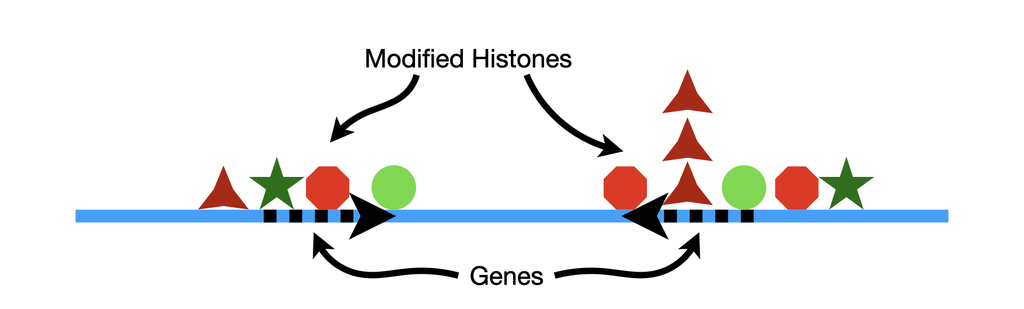

Because these datasets are so large (there are over 20,000 protein coding genes in the human genome), going through them by hand and observing correlations with gene activity is not possible. However, machine learning allows us to find correlations and identify active genes. In my mind, this makes machine learning a 21st century tool for science in much the same way that a microscope helped researchers in the 19th and 20th centuries.

This tutorial uses data from [The Encode Project](https://www.encodeproject.org/) derived from a cell line called [K562](https://en.wikipedia.org/wiki/K562_cells), which are human leukemia cells. First, I downloaded [total RNA-seq](https://www.encodeproject.org/files/ENCFF553DDU/@@download/ENCFF553DDU.tsv) data to identify active and inactive genes. This will allow us to determine if our simple machine learning method works or not. And, in order to make predictions, I downloaded ChIP-seq data for the following five histone modifications:

- [H3K27me3](https://www.encodeproject.org/files/ENCFF700RBU/@@download/ENCFF700RBU.bed.gz)
- [H3K36me3](https://www.encodeproject.org/files/ENCFF028HJF/@@download/ENCFF028HJF.bed.gz)
- [H3K4me1](https://www.encodeproject.org/files/ENCFF501DZN/@@download/ENCFF501DZN.bed.gz)
- [H3K4me3](https://www.encodeproject.org/files/ENCFF500EUY/@@download/ENCFF500EUY.bed.gz)
- [H3K9me3](https://www.encodeproject.org/files/ENCFF954LYH/@@download/ENCFF954LYH.bed.gz)

All datasets were aligned to [GRCh38](https://www.ncbi.nlm.nih.gov/assembly/GCF_000001405.26/), which is a version of the human genome curated by the [Genome Reference Consortium](https://www.ncbi.nlm.nih.gov/grc).

## Load (and possibly install) Packages to do the Work

Even though *R* is designed from the ground up for data analysis and pretty much everything we need is built into the base language, we still need to add some functionality to get this job done. *NOTE:* If you don't have the packages, you only need to install them, with `install.packages()`, once. After that initial installation, all we need to do is load the packages with `library()` each time we start up R and want to run this code.

```r
# install.packages("naivebayes") ## the naive bayes package does... Naive Bayes
library(naivebayes)
# install.packages("caret") ## for the confusion matrix
library(caret)
# install.packages("e1071") ## also for the confusion matrix
library(e1071)
##
## We also want to load ggplot2 (install if you don't already have it)
## so that our graphs look nice...
# install.packages("ggplot2")
library(ggplot2)
# install.packages("cowplot") # and cowplot makes ggplot2 look even better.
library(cowplot)
theme_set(theme_cowplot())
```

## Import the RNA-seq data

First, let's load in the RNA-seq data. This means we will read the data into a DataFrame, The data are organized in rows and columns and each row can contain a mixture of text and numbers.

```r
rnaseq <- read.delim(file="rnaseq.tsv", sep="\t", stringsAsFactors=FALSE, header=TRUE)
```

Now that we have loaded the data into a **DataFrame** called **rnaseq**, let's look at the first five rows using the `head()` function:

```r
head(rnaseq)
```

```
##   gene_id transcript_id.s. length effective_length expected_count TPM FPKM
## 1   21175            21175     86                0              0   0    0
## 2   21176            21176     74                0              0   0    0
## 3   21177            21177     72                0              0   0    0
## 4   21178            21178     71                0              0   0    0
## 5   21179            21179     74                0              0   0    0
## 6   21180            21180     73                0              0   0    0
##   posterior_mean_count posterior_standard_deviation_of_count pme_TPM pme_FPKM
## 1                    0                                     0       0        0
## 2                    0                                     0       0        0
## 3                    0                                     0       0        0
## 4                    0                                     0       0        0
## 5                    0                                     0       0        0
## 6                    0                                     0       0        0
##   TPM_ci_lower_bound TPM_ci_upper_bound FPKM_ci_lower_bound FPKM_ci_upper_bound
## 1                  0                  0                   0                   0
## 2                  0                  0                   0                   0
## 3                  0                  0                   0                   0
## 4                  0                  0                   0                   0
## 5                  0                  0                   0                   0
## 6                  0                  0                   0                   0
```

OK, so the first thing we see are `gene_ids` that are just numbers and not gene names. Depending on whether or not we also have the gene coordinates (chromosome number and position), this could be a problem. Looking at the other columns, I do not see gene coordinates so we have to figure out what these numbers mean and how we can translate them into gene names, and, ultimately, how those gene names can be associated with genomic coordinates.

Fortunately, a quick google search Google search on the terms "encode gene id to gene name" told me that if a `gene_id` is just a number, then it corresponds to **tRNA** and **pseudo_tRNA** sequences, and this is confirmed by the length of these genes (which are all less than 100 bp). I then read that if we scrolled down a bunch, we will see **ENSEMBL** gene ids like `ENSG00000000003.10`. So let's look and see if we can find the **ENSEMBL** gene ids. We'll do this by first determining how many genes are in the file using printing out the number of rows in the DataFrame with `nrow()`.

```r
nrow(rnaseq)
```

```
## [1] 58540
```

Since there are 58,540 rows in this file, we can pick a few in the middle to see if there have proper ENSEMBL gene ids.

```r
rnaseq[20000:20005,]
```

```
##                 gene_id  transcript_id.s. length effective_length
## 20000 ENSG00000201279.1 ENST00000364409.1     97             0.00
## 20001 ENSG00000201282.1 ENST00000364412.1    102             0.00
## 20002 ENSG00000201283.1 ENST00000364413.1    107             0.00
## 20003 ENSG00000201285.1 ENST00000364415.1    116             0.00
## 20004 ENSG00000201287.1 ENST00000364417.1    303           100.49
## 20005 ENSG00000201288.1 ENST00000364418.1    107             0.00
##       expected_count TPM FPKM posterior_mean_count
## 20000              0   0    0                    0
## 20001              0   0    0                    0
## 20002              0   0    0                    0
## 20003              0   0    0                    0
## 20004              0   0    0                    0
## 20005              0   0    0                    0
##       posterior_standard_deviation_of_count pme_TPM pme_FPKM TPM_ci_lower_bound
## 20000                                     0    0.00     0.00        0.00000e+00
## 20001                                     0    0.00     0.00        0.00000e+00
## 20002                                     0    0.00     0.00        0.00000e+00
## 20003                                     0    0.00     0.00        0.00000e+00
## 20004                                     0    0.09     0.21        1.67714e-07
## 20005                                     0    0.00     0.00        0.00000e+00
##       TPM_ci_upper_bound FPKM_ci_lower_bound FPKM_ci_upper_bound
## 20000           0.000000         0.00000e+00            0.000000
## 20001           0.000000         0.00000e+00            0.000000
## 20002           0.000000         0.00000e+00            0.000000
## 20003           0.000000         0.00000e+00            0.000000
## 20004           0.280282         3.73323e-07            0.624484
## 20005           0.000000         0.00000e+00            0.000000
```

Hooray!!! When we look at the rows in the middle of the DataFrame, we see proper ENSEMBL gene ids. We can use these to determine the **Transcription Start Sites (TSSs)** for each gene. Once we identify the TSSs, we can determine if the ChIP-seq data is enriched in those regions and use machine learning to determine if those enriched sites correlate with gene activity or not. However, first let's remove **tRNA** and **pseudo_tRNA** data, since we can not associate those numeric IDs with a corresponding TSS. We can do this by selecting all of the `gene_ids` that start with **ENSG** and putting them into a new DataFrame called `ensembl_gene_df`.

```r
ensembl_gene <- subset(rnaseq, grepl("ENSG", gene_id, perl=TRUE))
## Alternatively, we could have written
## ensembl_gene <- rnaseq[grepl("ENSG", rnaseq$gene_id, perl=TRUE)),]
head(ensembl_gene)
```

```
##                gene_id
## 625 ENSG00000000003.10
## 626  ENSG00000000005.5
## 627  ENSG00000000419.8
## 628  ENSG00000000457.9
## 629 ENSG00000000460.12
## 630  ENSG00000000938.8
##                                                                                                                                                                        transcript_id.s.
## 625                                                                                                                               ENST00000373020.4,ENST00000494424.1,ENST00000496771.1
## 626                                                                                                                                                 ENST00000373031.4,ENST00000485971.1
## 627                                                       ENST00000371582.4,ENST00000371583.5,ENST00000371584.4,ENST00000371588.5,ENST00000413082.1,ENST00000466152.1,ENST00000494752.1
## 628                                                                                           ENST00000367770.1,ENST00000367771.6,ENST00000367772.4,ENST00000423670.1,ENST00000470238.1
## 629 ENST00000286031.6,ENST00000359326.4,ENST00000413811.2,ENST00000456684.1,ENST00000459772.1,ENST00000466580.2,ENST00000472795.1,ENST00000481744.1,ENST00000496973.1,ENST00000498289.1
## 630                                     ENST00000374003.3,ENST00000374004.1,ENST00000374005.3,ENST00000399173.1,ENST00000457296.1,ENST00000468038.1,ENST00000475472.1,ENST00000545953.1
##      length effective_length expected_count   TPM  FPKM posterior_mean_count
```

[output cut: 20 more lines]

**NOTE:** In the output from the `head()` function, we see that a single value for `gene_id` can map to many different (comma separated) values for `transcript_id(s)`. This means that we know the read counts on a gene level, but can not tell if one specific transcript gets more reads than another. Ideally, we would have read counts on a transcript level, but since this is not the case, we must and make the best of what we have. **SPOILER ALERT** Even with this simplification, **Naive Bayes** still performs pretty well!!

Now we can determine how many **tRNA** and **pseduo_tRNAs** we removed by doing a little math with the output from `nrow()`.

```r
nrow(rnaseq) - nrow(ensembl_gene)
```

```
## [1] 720
```

So we removed 720 **tRNA** and **pseduo_tRNAs**.

Now let's make our lives a little simpler by keeping the two columns we need `gene_id` and `posterior_mean_count`, and omitting all of the columns we do not need.

```r
ensembl_gene <- ensembl_gene[, c("gene_id", "posterior_mean_count")]
head(ensembl_gene)
```

```
##                gene_id posterior_mean_count
## 625 ENSG00000000003.10                    0
## 626  ENSG00000000005.5                    0
## 627  ENSG00000000419.8                 1910
## 628  ENSG00000000457.9                  498
## 629 ENSG00000000460.12                 1328
## 630  ENSG00000000938.8                    0
```

Lastly, we can make our life a lot easier later on if we rename the second column `posterior_mean_count` to just `count`.

```r
colnames(ensembl_gene)[2] <- "count"
head(ensembl_gene)
```

```
##                gene_id count
## 625 ENSG00000000003.10     0
## 626  ENSG00000000005.5     0
## 627  ENSG00000000419.8  1910
## 628  ENSG00000000457.9   498
## 629 ENSG00000000460.12  1328
## 630  ENSG00000000938.8     0
```

## Merging the RNA-seq data with Transcription Start Sites (TSSs)

Because `ensembl_gene_df` does not have the TSS locations, we have to download them from Ensembl's [BioMart](http://uswest.ensembl.org/biomart/martview/), import them and merge them with the data we have. We can get the data from BioMart by selecting the **Ensembl Genes Database** for **Human Genes (GRCh38)** and, from the **Attributes** section, selecting **Gene stable ID**, **Chromosome/scaffold name** and **Transcription start site (TSS)** with this query. So now let's load in the file with the TSS coordinates and look at the first few rows.

```r
tss_data <- read.delim(file="ensembl_geneids_to_tss.txt.gz", sep="\t", stringsAsFactors=FALSE, header=TRUE)
head(tss_data)
```

```
##    Gene.stable.ID Gene.stable.ID.version Transcript.stable.ID
## 1 ENSG00000210049      ENSG00000210049.1      ENST00000387314
## 2 ENSG00000211459      ENSG00000211459.2      ENST00000389680
## 3 ENSG00000210077      ENSG00000210077.1      ENST00000387342
## 4 ENSG00000210082      ENSG00000210082.2      ENST00000387347
## 5 ENSG00000209082      ENSG00000209082.1      ENST00000386347
## 6 ENSG00000198888      ENSG00000198888.2      ENST00000361390
##   Transcript.stable.ID.version Chromosome.scaffold.name Gene.start..bp.
## 1            ENST00000387314.1                       MT             577
## 2            ENST00000389680.2                       MT             648
## 3            ENST00000387342.1                       MT            1602
## 4            ENST00000387347.2                       MT            1671
## 5            ENST00000386347.1                       MT            3230
## 6            ENST00000361390.2                       MT            3307
##   Gene.end..bp. Strand Transcription.start.site..TSS.
## 1           647      1                            577
## 2          1601      1                            648
## 3          1670      1                           1602
## 4          3229      1                           1671
## 5          3304      1                           3230
## 6          4262      1                           3307
```

Now, in order to make our lives, easier, let's give the columns we are interested in, `Gene stable ID`, `Chromosome/scaffold name` and `Transcription start site (TSS)` shorter names...

```r
colnames(tss_data)[c(1, 5, 9)] <- c("gene_id_stable", "chr", "tss")
head(tss_data)
```

```
##    gene_id_stable Gene.stable.ID.version Transcript.stable.ID
## 1 ENSG00000210049      ENSG00000210049.1      ENST00000387314
## 2 ENSG00000211459      ENSG00000211459.2      ENST00000389680
## 3 ENSG00000210077      ENSG00000210077.1      ENST00000387342
## 4 ENSG00000210082      ENSG00000210082.2      ENST00000387347
## 5 ENSG00000209082      ENSG00000209082.1      ENST00000386347
## 6 ENSG00000198888      ENSG00000198888.2      ENST00000361390
##   Transcript.stable.ID.version chr Gene.start..bp. Gene.end..bp. Strand  tss
## 1            ENST00000387314.1  MT             577           647      1  577
## 2            ENST00000389680.2  MT             648          1601      1  648
## 3            ENST00000387342.1  MT            1602          1670      1 1602
## 4            ENST00000387347.2  MT            1671          3229      1 1671
## 5            ENST00000386347.1  MT            3230          3304      1 3230
## 6            ENST00000361390.2  MT            3307          4262      1 3307
```

...and let's make our lives a little simpler by just keeping the columns we are interested in and omitting the rest.

```r
tss_data <- tss_data[,c("gene_id_stable", "chr", "tss")]
head(tss_data)
```

```
##    gene_id_stable chr  tss
## 1 ENSG00000210049  MT  577
## 2 ENSG00000211459  MT  648
## 3 ENSG00000210077  MT 1602
## 4 ENSG00000210082  MT 1671
## 5 ENSG00000209082  MT 3230
## 6 ENSG00000198888  MT 3307
```

**NOTE:** Because we downloaded **Gene stable IDs** from BioMart, we have to convert the gene IDs in `ensembl_gene` to stable gene ids. Stable gene IDs are the ENSG IDs that we have, but everything after the "dot" is excluded. For example, if we look at the first 5 gene IDs in `ensembl_gene` with `head()`...

```r
head(ensembl_gene$gene_id)
```

```
## [1] "ENSG00000000003.10" "ENSG00000000005.5"  "ENSG00000000419.8"
## [4] "ENSG00000000457.9"  "ENSG00000000460.12" "ENSG00000000938.8"
```

...we see that each gene id ends in "dot some number". We need to remove the "dot some number", so we'll do this with something called a **Regular Expression**. **Regular Expressions** can be very cryptic and are beyond the scope of this notebook, however, just know that they are like a "search and replace" tool on steroids. In this case, we'll use a **Regular Expression** to extract the stable IDs and put them into a new variable called `gene_id_stable`.

```r
## NOTE: I found out while I was doing this that Ensembl starts most gene names with "ENSG", but it starts genes
## that are on the pseudo-autosomal region on the Y-chromosome with "ENSGR" because it allows them to add two
## sets of coordinates for a single gene (one set of coordinates for the X chromosome and one set for the Y chromosome)
## to a GTF file (which is a file used by programs that count reads per gene).
gene_id_stable <- sub(pattern="\\.\\d+", replacement="", ensembl_gene$gene_id)
gene_id_stable[0:4]
```

```
## [1] "ENSG00000000003" "ENSG00000000005" "ENSG00000000419" "ENSG00000000457"
```

Now that we have the stable gene IDs, let's add them to `ensembl_gene_df` by creating a new column called `gene_id_stable`.

```r
ensembl_gene$gene_id_stable <- gene_id_stable
head(ensembl_gene)
```

```
##                gene_id count  gene_id_stable
## 625 ENSG00000000003.10     0 ENSG00000000003
## 626  ENSG00000000005.5     0 ENSG00000000005
## 627  ENSG00000000419.8  1910 ENSG00000000419
## 628  ENSG00000000457.9   498 ENSG00000000457
## 629 ENSG00000000460.12  1328 ENSG00000000460
## 630  ENSG00000000938.8     0 ENSG00000000938
```

Now we can merge `ensembl_gene_df` with `tss_df` based on `gene_id_stable` using the `merge()` function.

```r
count_and_tss <- merge(ensembl_gene, tss_data, by="gene_id_stable")
head(count_and_tss)
```

```
##    gene_id_stable            gene_id count chr       tss
## 1 ENSG00000000003 ENSG00000000003.10     0   X 100637104
## 2 ENSG00000000003 ENSG00000000003.10     0   X 100639991
## 3 ENSG00000000003 ENSG00000000003.10     0   X 100636689
## 4 ENSG00000000003 ENSG00000000003.10     0   X 100636806
## 5 ENSG00000000003 ENSG00000000003.10     0   X 100637104
## 6 ENSG00000000005  ENSG00000000005.5     0   X 100584936
```

Now, if look at the output from the last call to `head()`, we see that a single value for `gene_id` and `gene_id_stable` can map to multiple values in `tss`. We also saw this earlier when we first created the `ensembl_gene_df` DataFrame. Since we only have read counts per gene, and not per transcript, we have to just pick a single TSS per `gene_id`. This is not ideal, but like I mentioned before in a **SPOILER ALERT**, our model still performs pretty well.

```r
count_and_tss <- count_and_tss[!duplicated(count_and_tss$gene_id_stable),]
head(count_and_tss)
```

```
##     gene_id_stable            gene_id count chr       tss
## 1  ENSG00000000003 ENSG00000000003.10     0   X 100637104
## 6  ENSG00000000005  ENSG00000000005.5     0   X 100584936
## 8  ENSG00000000419  ENSG00000000419.8  1910  20  50958550
## 14 ENSG00000000457  ENSG00000000457.9   498   1 169893959
## 19 ENSG00000000460 ENSG00000000460.12  1328   1 169794730
## 28 ENSG00000000938  ENSG00000000938.8     0   1  27626240
```

```r
tss_bed <- count_and_tss[,c("chr", "tss", "tss", "gene_id_stable")]
head(tss_bed)
```

```
##    chr       tss     tss.1  gene_id_stable
## 1    X 100637104 100637104 ENSG00000000003
## 6    X 100584936 100584936 ENSG00000000005
## 8   20  50958550  50958550 ENSG00000000419
## 14   1 169893959 169893959 ENSG00000000457
## 19   1 169794730 169794730 ENSG00000000460
## 28   1  27626240  27626240 ENSG00000000938
```

Now we need to add the prefix **chr** to all of the chromosome numbers.

```r
tss_bed$chr <- paste0("chr", tss_bed$chr)
head(tss_bed)
```

```
##      chr       tss     tss.1  gene_id_stable
## 1   chrX 100637104 100637104 ENSG00000000003
## 6   chrX 100584936 100584936 ENSG00000000005
## 8  chr20  50958550  50958550 ENSG00000000419
## 14  chr1 169893959 169893959 ENSG00000000457
## 19  chr1 169794730 169794730 ENSG00000000460
## 28  chr1  27626240  27626240 ENSG00000000938
```

Now that we have the data in **BED** format, we can write it to a file and use **bedTools** to find ChIP-seq enrichment near each TSS.

```r
write.table(tss_bed, file="tss.bed", sep="\t", quote=FALSE, row.names=FALSE, col.names=FALSE)
```

```
bedtools window -a tss.bed -b h3k27me3.bed.gz -w 2000 -c > tss_h3k27me3.bed

bedtools window -a tss.bed -b h3k36me3.bed.gz -w 2000 -c > tss_h3k36me3.bed

bedtools window -a tss.bed -b h3k4me1.bed.gz -w 2000 -c > tss_h3k4me1.bed

bedtools window -a tss.bed -b h3k4me3.bed.gz -w 2000 -c > tss_h3k4me3.bed

bedtools window -a tss.bed -b h3k9me3.bed.gz -w 2000 -c > tss_h3k9me3.bed
```

Now we can load in the new files that show if the modified histones are enriched near the TSSs and merge them together. We will start by loading in `tss_h3k27me3.bed` and looking at the first 5 rows.

```r
tss_h3k27me3 <- read.delim(file="tss_h3k27me3.bed", sep="\t", header=FALSE, stringsAsFactors=FALSE)
head(tss_h3k27me3)
```

```
##      V1        V2        V3              V4 V5
## 1  chrX 100636806 100636806 ENSG00000000003  1
## 2  chrX 100584936 100584936 ENSG00000000005  0
## 3 chr20  50958532  50958532 ENSG00000000419  0
## 4  chr1 169893896 169893896 ENSG00000000457  0
## 5  chr1 169662007 169662007 ENSG00000000460  0
## 6  chr1  27635185  27635185 ENSG00000000938  2
```

Since the new file does not have column names, we can add column names...

```r
colnames(tss_h3k27me3) <- c("chr", "start", "stop", "gene_id_stable", "h3k27me3")
head(tss_h3k27me3)
```

```
##     chr     start      stop  gene_id_stable h3k27me3
## 1  chrX 100636806 100636806 ENSG00000000003        1
## 2  chrX 100584936 100584936 ENSG00000000005        0
## 3 chr20  50958532  50958532 ENSG00000000419        0
## 4  chr1 169893896 169893896 ENSG00000000457        0
## 5  chr1 169662007 169662007 ENSG00000000460        0
## 6  chr1  27635185  27635185 ENSG00000000938        2
```

...and, because we only need the last two columns (we need `gene_id_stable` to merge this file with `count_and_tss`, and we need `h3k27me3` because that has the number of enriched sites near the TSS), we can drop the first three columns.

```r
tss_h3k27me3 <- tss_h3k27me3[,c("gene_id_stable", "h3k27me3")]
head(tss_h3k27me3)
```

```
##    gene_id_stable h3k27me3
## 1 ENSG00000000003        1
## 2 ENSG00000000005        0
## 3 ENSG00000000419        0
## 4 ENSG00000000457        0
## 5 ENSG00000000460        0
## 6 ENSG00000000938        2
```

Now we can merge the number of enriched sites with `count_and_tss`...

```r
count_and_tss <- merge(count_and_tss, tss_h3k27me3, by="gene_id_stable")
head(count_and_tss)
```

```
##    gene_id_stable            gene_id count chr       tss h3k27me3
## 1 ENSG00000000003 ENSG00000000003.10     0   X 100637104        1
## 2 ENSG00000000005  ENSG00000000005.5     0   X 100584936        0
## 3 ENSG00000000419  ENSG00000000419.8  1910  20  50958550        0
## 4 ENSG00000000457  ENSG00000000457.9   498   1 169893959        0
## 5 ENSG00000000460 ENSG00000000460.12  1328   1 169794730        0
## 6 ENSG00000000938  ENSG00000000938.8     0   1  27626240        2
```

Now we just do the same thing for all of the other ChIP-seq files...

```r
tss_h3k36me3 <- read.delim(file="tss_h3k36me3.bed", sep="\t", header=FALSE, stringsAsFactors=FALSE)
colnames(tss_h3k36me3) <- c("chr", "start", "stop", "gene_id_stable", "h3k36me3")
tss_h3k36me3 <- tss_h3k36me3[,c("gene_id_stable", "h3k36me3")]
count_and_tss <- merge(count_and_tss, tss_h3k36me3, by="gene_id_stable")
head(count_and_tss)
```

```
##    gene_id_stable            gene_id count chr       tss h3k27me3 h3k36me3
## 1 ENSG00000000003 ENSG00000000003.10     0   X 100637104        1        0
## 2 ENSG00000000005  ENSG00000000005.5     0   X 100584936        0        0
## 3 ENSG00000000419  ENSG00000000419.8  1910  20  50958550        0        3
## 4 ENSG00000000457  ENSG00000000457.9   498   1 169893959        0        0
## 5 ENSG00000000460 ENSG00000000460.12  1328   1 169794730        0        0
## 6 ENSG00000000938  ENSG00000000938.8     0   1  27626240        2        0
```

```r
tss_h3k4me1 <- read.delim(file="tss_h3k4me1.bed", sep="\t", header=FALSE, stringsAsFactors=FALSE)
colnames(tss_h3k4me1) <- c("chr", "start", "stop", "gene_id_stable", "h3k4me1")
tss_h3k4me1 <- tss_h3k4me1[,c("gene_id_stable", "h3k4me1")]
count_and_tss <- merge(count_and_tss, tss_h3k4me1, by="gene_id_stable")
head(count_and_tss)
```

```
##    gene_id_stable            gene_id count chr       tss h3k27me3 h3k36me3
## 1 ENSG00000000003 ENSG00000000003.10     0   X 100637104        1        0
## 2 ENSG00000000005  ENSG00000000005.5     0   X 100584936        0        0
## 3 ENSG00000000419  ENSG00000000419.8  1910  20  50958550        0        3
## 4 ENSG00000000457  ENSG00000000457.9   498   1 169893959        0        0
## 5 ENSG00000000460 ENSG00000000460.12  1328   1 169794730        0        0
## 6 ENSG00000000938  ENSG00000000938.8     0   1  27626240        2        0
##   h3k4me1
## 1       1
## 2       0
## 3       2
## 4       2
## 5       0
## 6       1
```

```r
tss_h3k4me3 <- read.delim(file="tss_h3k4me3.bed", sep="\t", header=FALSE, stringsAsFactors=FALSE)
colnames(tss_h3k4me3) <- c("chr", "start", "stop", "gene_id_stable", "h3k4me3")
tss_h3k4me3 <- tss_h3k4me3[,c("gene_id_stable", "h3k4me3")]
count_and_tss <- merge(count_and_tss, tss_h3k4me3, by="gene_id_stable")
head(count_and_tss)
```

```
##    gene_id_stable            gene_id count chr       tss h3k27me3 h3k36me3
## 1 ENSG00000000003 ENSG00000000003.10     0   X 100637104        1        0
## 2 ENSG00000000005  ENSG00000000005.5     0   X 100584936        0        0
## 3 ENSG00000000419  ENSG00000000419.8  1910  20  50958550        0        3
## 4 ENSG00000000457  ENSG00000000457.9   498   1 169893959        0        0
## 5 ENSG00000000460 ENSG00000000460.12  1328   1 169794730        0        0
## 6 ENSG00000000938  ENSG00000000938.8     0   1  27626240        2        0
##   h3k4me1 h3k4me3
## 1       1       0
## 2       0       0
## 3       2       1
## 4       2       1
## 5       0       1
## 6       1       1
```

```r
tss_h3k9me3 <- read.delim(file="tss_h3k9me3.bed", sep="\t", header=FALSE, stringsAsFactors=FALSE)
colnames(tss_h3k9me3) <- c("chr", "start", "stop", "gene_id_stable", "h3k9me3")
tss_h3k9me3 <- tss_h3k9me3[,c("gene_id_stable", "h3k9me3")]
count_and_tss <- merge(count_and_tss, tss_h3k9me3, by="gene_id_stable")
head(count_and_tss)
```

```
##    gene_id_stable            gene_id count chr       tss h3k27me3 h3k36me3
## 1 ENSG00000000003 ENSG00000000003.10     0   X 100637104        1        0
## 2 ENSG00000000005  ENSG00000000005.5     0   X 100584936        0        0
## 3 ENSG00000000419  ENSG00000000419.8  1910  20  50958550        0        3
## 4 ENSG00000000457  ENSG00000000457.9   498   1 169893959        0        0
## 5 ENSG00000000460 ENSG00000000460.12  1328   1 169794730        0        0
## 6 ENSG00000000938  ENSG00000000938.8     0   1  27626240        2        0
##   h3k4me1 h3k4me3 h3k9me3
## 1       1       0       0
## 2       0       0       0
## 3       2       1       0
## 4       2       1       0
## 5       0       1       0
## 6       1       1       0
```

**BAM!!!** We merged the RNA-seq data with the ChIP-seq data.

## Classify genes as Active or Not Active

Now we need to classify genes as "active" or "not active". However, first, let's draw a boxplot of the values in `count` to see how the genes are spread out.

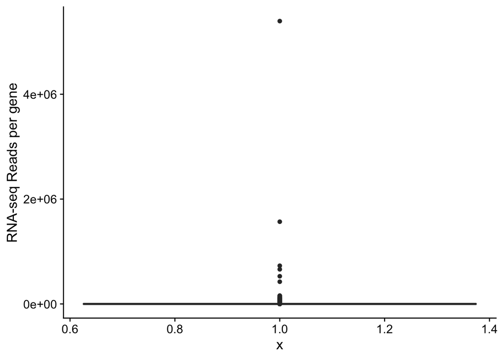

```r
ggplot(data=count_and_tss, aes(x=1, y=count)) +
  geom_boxplot() +
  ylab("RNA-seq Reads per gene")
```

And we see that most genes have relative low read counts. We can also print out a summary of the values in `count` to see the quantiles.

```r
summary(count_and_tss$count)
```

```
##    Min. 1st Qu.  Median    Mean 3rd Qu.    Max.
##       0       0       0     817      22 5395174
```

Confirming what we saw in the boxplot, most genes have 0 reads. So let's see what happens if we say that if a gene has > 0 reads, it is *active*, otherwise it is *inactive*. We can do that by creating a new column `active` and setting it to `True` when there is more than 1 read associated with that gene. Otherwise we will set the value to `False`.

**NOTE:** I'm setting the threshold for *active* to be greater than 1 because, who knows, maybe random fragments aligned to genes and this might help filter out some noise.

```r
count_and_tss$active <- (count_and_tss$count > 1)
head(count_and_tss)
```

```
##    gene_id_stable            gene_id count chr       tss h3k27me3 h3k36me3
## 1 ENSG00000000003 ENSG00000000003.10     0   X 100637104        1        0
## 2 ENSG00000000005  ENSG00000000005.5     0   X 100584936        0        0
## 3 ENSG00000000419  ENSG00000000419.8  1910  20  50958550        0        3
## 4 ENSG00000000457  ENSG00000000457.9   498   1 169893959        0        0
## 5 ENSG00000000460 ENSG00000000460.12  1328   1 169794730        0        0
## 6 ENSG00000000938  ENSG00000000938.8     0   1  27626240        2        0
##   h3k4me1 h3k4me3 h3k9me3 active
## 1       1       0       0  FALSE
## 2       0       0       0  FALSE
## 3       2       1       0   TRUE
## 4       2       1       0   TRUE
## 5       0       1       0   TRUE
## 6       1       1       0  FALSE
```

Since `TRUE` is equal to `1`, and `FALSE` is equal to `0`, we can determine the number of active genes by adding together the values in `active`.

```r
sum(count_and_tss$active)
```

```
## [1] 17949
```

## Visualizing the difference in ChIP-seq data for Active and Not Active Genes

At this point, before we try to apply Naive Bayes to the data, we should graph the average counts for each ChIP-seq enrichment to see if there are differences between *active* and *inactive* genes. So, first, let's calculate the average the number of enriched sites for each ChIP-seq dataset, keeping separate tallies for *active* and *inactive* genes.

```r
## The general idea in the code below for calculating the average number of
## of enriched Histone modifications is:
##  1) We select only the rows in count_and_tss where the value in the column
##     'active' is True (or False) and add up the number of enriched sites.
##  2) Divide by the number number of rows in count_and_tss where the value in
##     'active' is True (or False)
##
## For example, to cacluate the average number of enriched h3k27me3 sites
## near the TSSs of active genes, we select the 'active' genes with this...
##
##   count_and_tss[count_and_tss$active == True,]
##
## ...of the rows where 'active' == True, we then specify which column
## we are interested in, h3k27me3, by adding $h3k27me3 like this...
##
##   count_and_tss[count_and_tss$active == True,]$h3k27me3
##
## ...we then divide divide by the number of active genes with this...
##
##   / nrow(count_and_tss[count_and_tss$active == True])
##

## h3k27me3
h3k27me3_active <-
  sum(count_and_tss[count_and_tss$active == TRUE,]$h3k27me3) /
                    nrow(count_and_tss[count_and_tss$active == TRUE,])
h3k27me3_inactive <-
  sum(count_and_tss[count_and_tss$active == FALSE,]$h3k27me3) /
                    nrow(count_and_tss[count_and_tss$active == FALSE,])

## h3k36me3
h3k36me3_active <-
  sum(count_and_tss[count_and_tss$active == TRUE,]$h3k36me3) /
                    nrow(count_and_tss[count_and_tss$active == TRUE,])
h3k36me3_inactive <-
  sum(count_and_tss[count_and_tss$active == FALSE,]$h3k36me3) /
                    nrow(count_and_tss[count_and_tss$active == FALSE,])

## h3k4me1
h3k4me1_active <-
  sum(count_and_tss[count_and_tss$active == TRUE,]$h3k4me1) /
                    nrow(count_and_tss[count_and_tss$active == TRUE,])
h3k4me1_inactive <-
  sum(count_and_tss[count_and_tss$active == FALSE,]$h3k4me1) /
                    nrow(count_and_tss[count_and_tss$active == FALSE,])

## h3k4me3
h3k4me3_active <-
  sum(count_and_tss[count_and_tss$active == TRUE,]$h3k4me3) /
                    nrow(count_and_tss[count_and_tss$active == TRUE,])
h3k4me3_inactive <-
  sum(count_and_tss[count_and_tss$active == FALSE,]$h3k4me3) /
                    nrow(count_and_tss[count_and_tss$active == FALSE,])

## h3k9me3
h3k9me3_active <-
  sum(count_and_tss[count_and_tss$active == TRUE,]$h3k9me3) /
                    nrow(count_and_tss[count_and_tss$active == TRUE,])
h3k9me3_inactive <-
  sum(count_and_tss[count_and_tss$active == FALSE,]$h3k9me3) /
                    nrow(count_and_tss[count_and_tss$active == FALSE,])
```

Now let's combine all of the data into a new DataFrame that we can use as input to a graphing function...

```r
chip_counts_df <- data.frame(
  chip = c("h3k27me3", "h3k27me3",
           "h3k36me3", "h3k36me3",
           "h3k4me1", "h3k4me1",
           "h3k4me3", "h3k4me3",
           "h3k9me3", "h3k9me3"),
  status = c("active", "inactive",
             "active", "inactive",
             "active", "inactive",
             "active", "inactive",
             "active", "inactive"),
  avg_count = c(h3k27me3_active, h3k27me3_inactive,
            h3k36me3_active, h3k36me3_inactive,
            h3k4me1_active, h3k4me1_inactive,
            h3k4me3_active, h3k4me3_inactive,
            h3k9me3_active, h3k9me3_inactive))
head(chip_counts_df)
```

```
##       chip   status avg_count
## 1 h3k27me3   active 0.2571174
## 2 h3k27me3 inactive 0.6644737
## 3 h3k36me3   active 0.6966405
## 4 h3k36me3 inactive 0.2600585
## 5  h3k4me1   active 1.7475068
## 6  h3k4me1 inactive 0.5457018
```

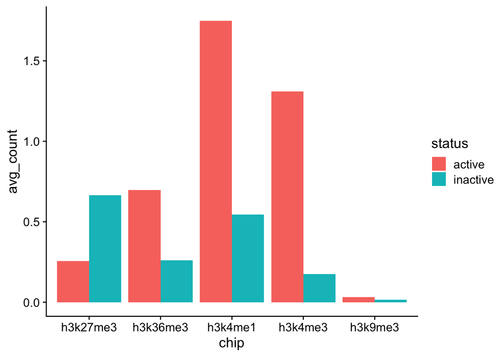

```r
ggplot(data=chip_counts_df, aes(x=chip, y=avg_count, fill=status)) +
         geom_bar(stat="identity", position="dodge")
```

Generally speaking, it looks like, on average, there are more enriched regions of **H3K27me3** around the TSSs of *inactive* genes, and more enriched regions of **H3K36me3**, **H3K4me1** and **H3K4me3** around the TSSs of *active* genes. **H3K9me3** does not look very different between *active* and *inactive* genes.

## Applying Naive Bayes to our data

First, let's split the data into independent and dependent variables. Traditionally, the independent variables (in this example, the ChIP-seq data are the independent variables because we are using them to make predictions) are stored in a variable called `X` (upper case **X**), and the dependent variable (`active`, because we are predicting this value) is stored in a variable called `y` (lower case **y**). Let's start by creating `X`.

```r
X <- count_and_tss[,c("h3k27me3",
                      "h3k36me3",
                      "h3k4me1",
                      "h3k4me3",
                      "h3k9me3")]
rownames(X) <- count_and_tss$gene_id_stable
head(X)
```

```
##                 h3k27me3 h3k36me3 h3k4me1 h3k4me3 h3k9me3
## ENSG00000000003        1        0       1       0       0
## ENSG00000000005        0        0       0       0       0
## ENSG00000000419        0        3       2       1       0
## ENSG00000000457        0        0       2       1       0
## ENSG00000000460        0        0       0       1       0
## ENSG00000000938        2        0       1       1       0
```

Now let's create `y`.

```r
y <- count_and_tss$active
head(y)
```

```
## [1] FALSE FALSE  TRUE  TRUE  TRUE FALSE
```

Now that we have `X` and `y`, we can split them into training and testing datasets.

```r
## split the data into training and testing sets
## 75% of the sample size
sample_size <- floor(0.75 * nrow(X))

set.seed(42)
train_indices <- sample(1:nrow(X), size = sample_size)

X_train <- X[train_indices,]
X_test <- X[-train_indices,]
y_train <- y[train_indices]
y_test <- y[-train_indices]
```

Now the part we've been waiting for. We train the Naive Bayes model, test it and draw a [confusion matrix](https://youtu.be/Kdsp6soqA7o). Just 3 lines of code!!!

```r
## NOTE: setting laplace is setting the value for alpha
clf <- multinomial_naive_bayes(x=as.matrix(X_train), y=y_train, laplace=1)
predictions <- predict(clf, newdata=as.matrix(X_test), type="class")
confusionMatrix(reference=predictions,
                data=as.factor(y_test),
                dnn=c("True Label", "Predicted Label"))
```

```
## Confusion Matrix and Statistics
##
##           Predicted Label
## True Label FALSE TRUE
##      FALSE  7592  978
##      TRUE   1435 3033
##
##                Accuracy : 0.8149
##                  95% CI : (0.8082, 0.8216)
##     No Information Rate : 0.6924
##     P-Value [Acc > NIR] : < 2.2e-16
##
##                   Kappa : 0.5789
##
##  Mcnemar's Test P-Value : < 2.2e-16
##
##             Sensitivity : 0.8410
##             Specificity : 0.7562
##          Pos Pred Value : 0.8859
##          Neg Pred Value : 0.6788
##              Prevalence : 0.6924
##          Detection Rate : 0.5823
##    Detection Prevalence : 0.6573
##       Balanced Accuracy : 0.7986
##
##        'Positive' Class : FALSE
##
```

So, off the...

```r
length(y_test)
```

```
## [1] 13038
```

...genes in the testing dataset, we correctly classified...

```r
sum(predictions == y_test)
```

```
## [1] 10625
```

...genes, or 81%, which is pretty good for a very simple model and the possibility that we are not always using the correct TSS for each gene.

## DOUBLE BAM!!!!

Now, I wouldn't be surprised if some of you are thinking, "What's the big deal? We already knew which genes were active an inactive from the RNA-seq data." And that is a very valid thing to think. However, consider that the method and approach that we just used can be applied to all kinds of situations in genomics. For example, if we only have a handful of known enhancer or promoter regions, we could use this method to identify more of them. And if we wanted to use a fancier machine learning method, like [Support Vector Machines](https://youtu.be/efR1C6CvhmE) or [Neural Networks](https://youtu.be/CqOfi41LfDw), we only need to make minor changes to those three lines of code that trained and tested the Naive Bayes classifier. So, even though the discovery we made in this Notebook isn't ground breaking, the method can lead you to so many more discoveries, and I think that is pretty amazing!!!!